# trial-b fit overview

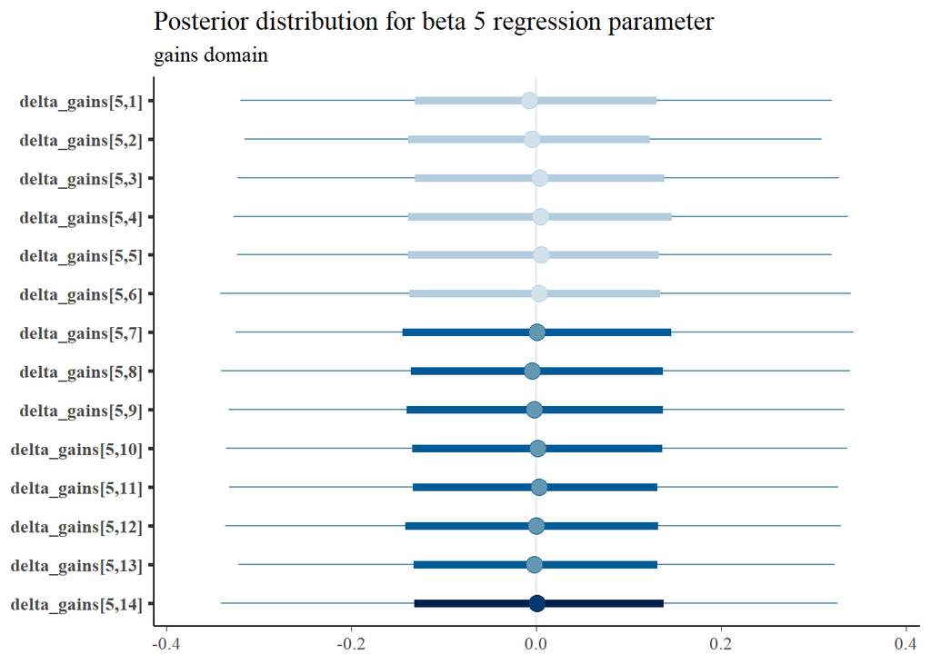

```
##
## [[5]][[2]]
```

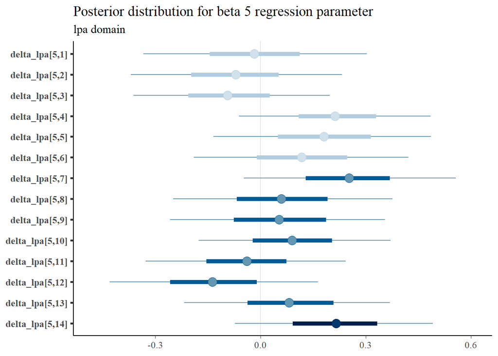

```
##
## [[5]][[3]]
```

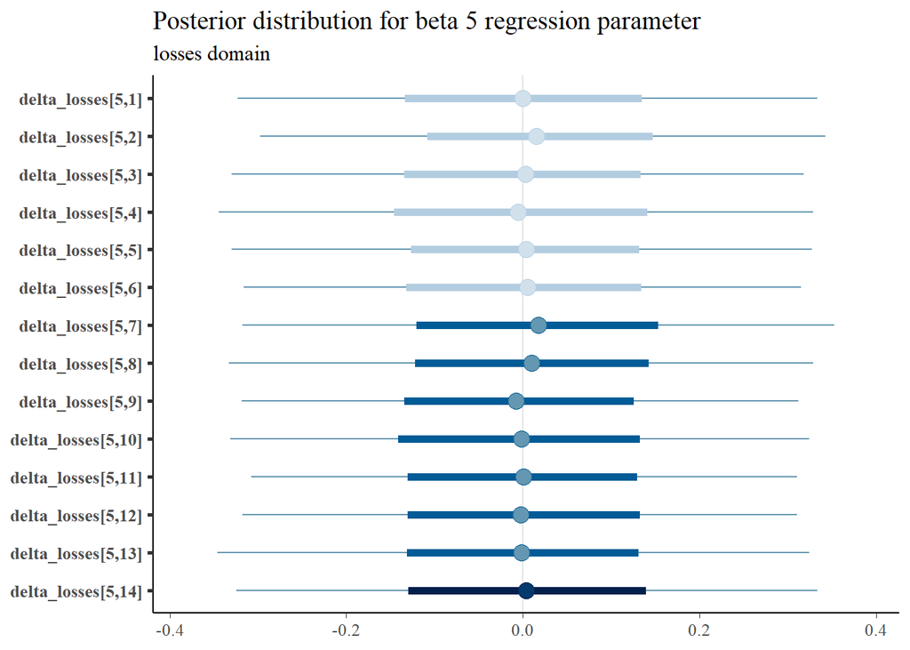

```
##
##
## [[6]]
## [[6]][[1]]
```

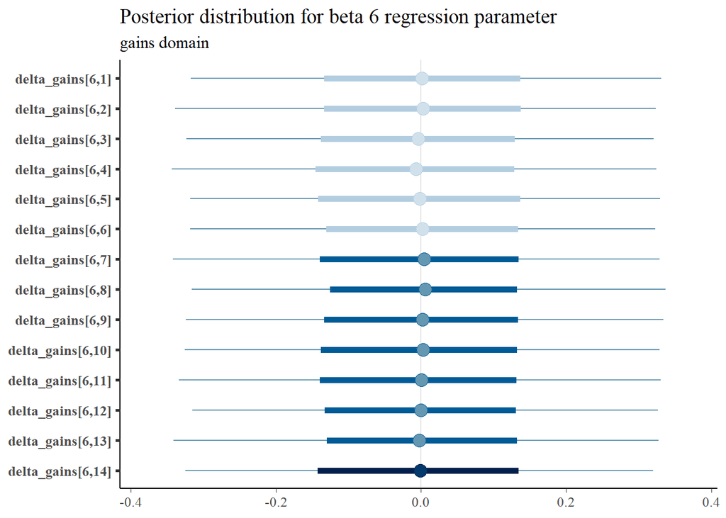

```
##
## [[6]][[2]]
```

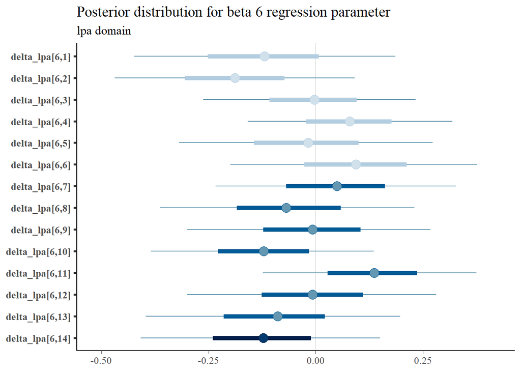

```
##
## [[6]][[3]]
```

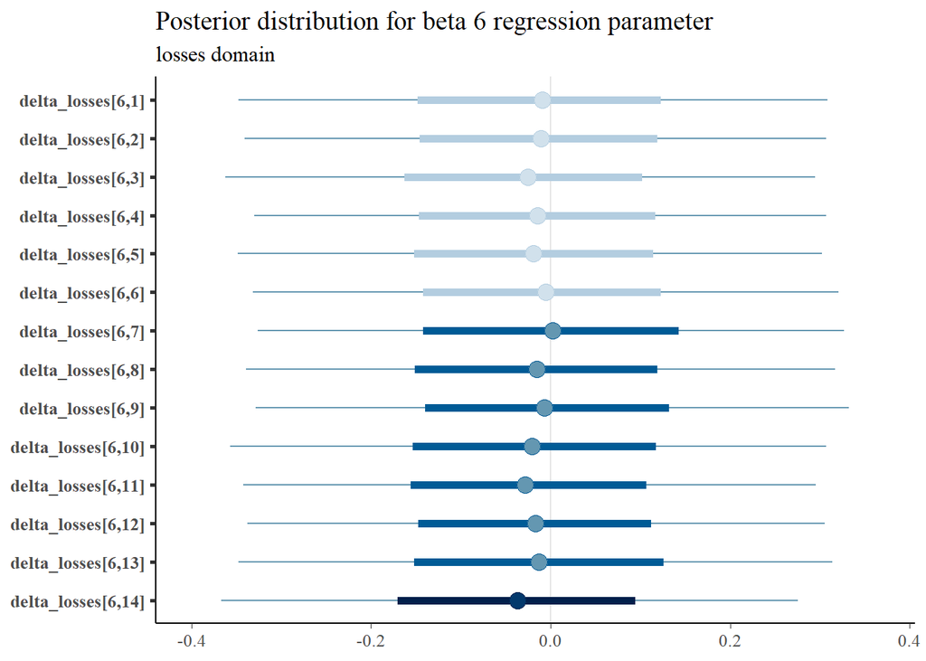

```
##
##
## [[7]]
## [[7]][[1]]
```

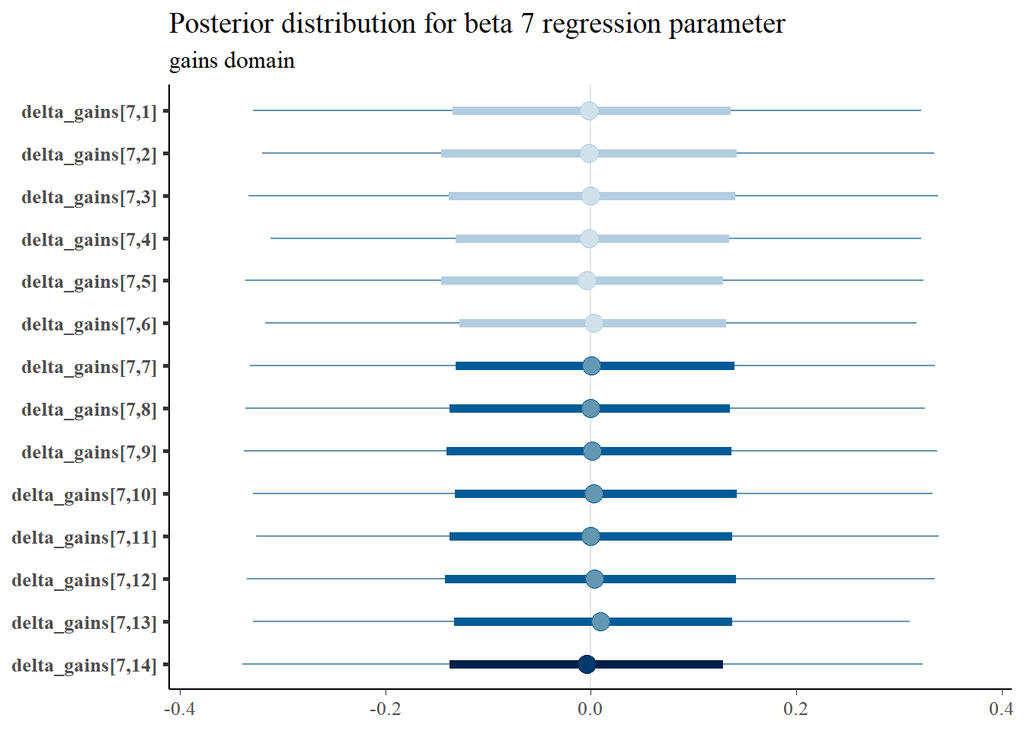

```
##
## [[7]][[2]]
```

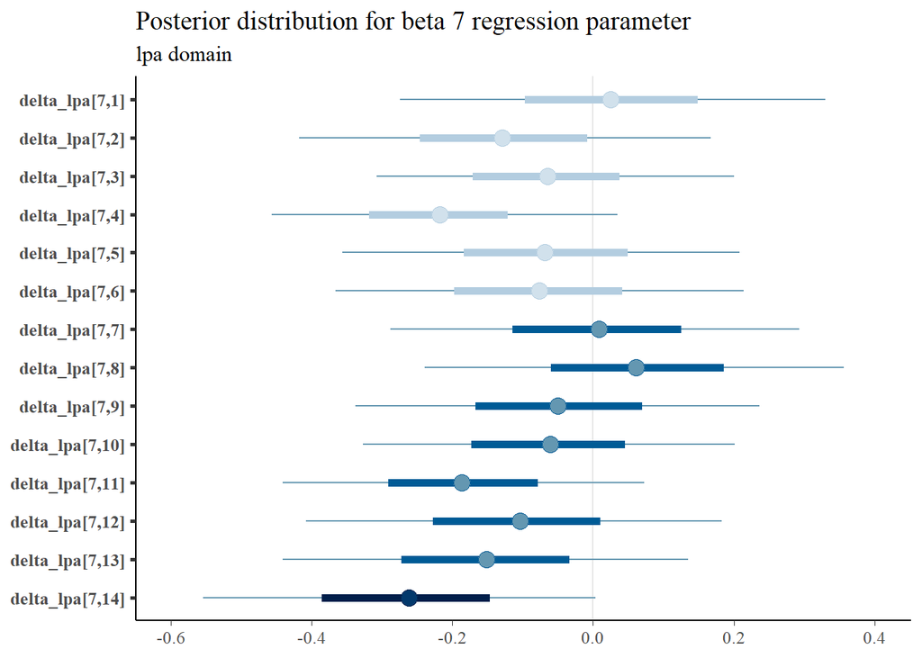

```
##
## [[7]][[3]]
```

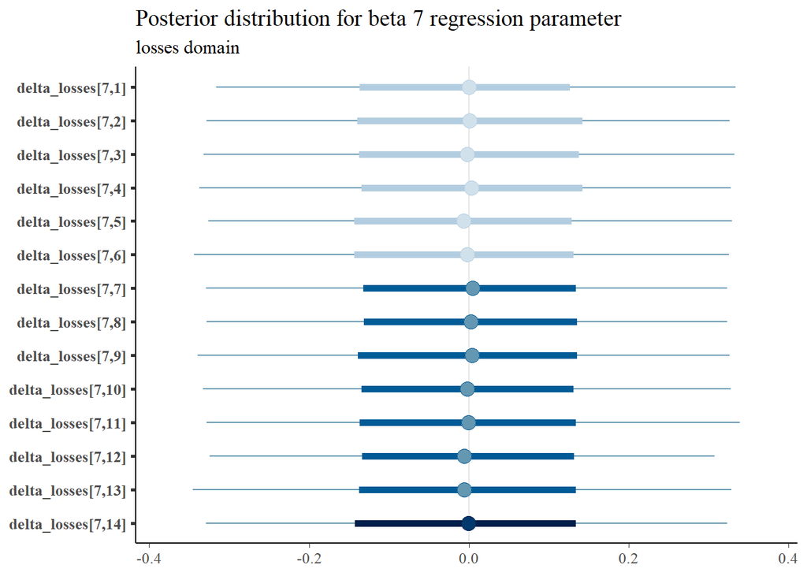

```
##
##
## [[8]]
## [[8]][[1]]
```

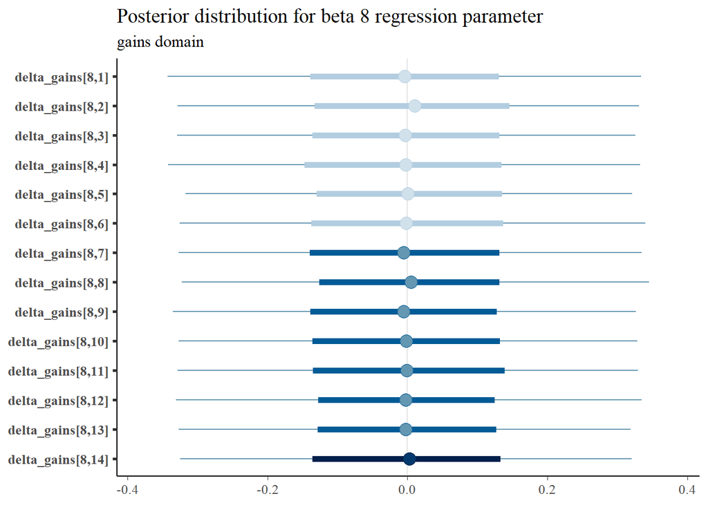

```
##
## [[8]][[2]]
```

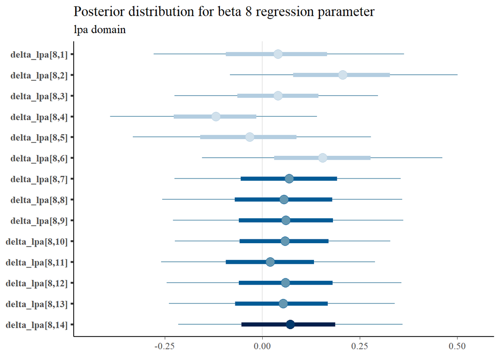

```
##
## [[8]][[3]]
```

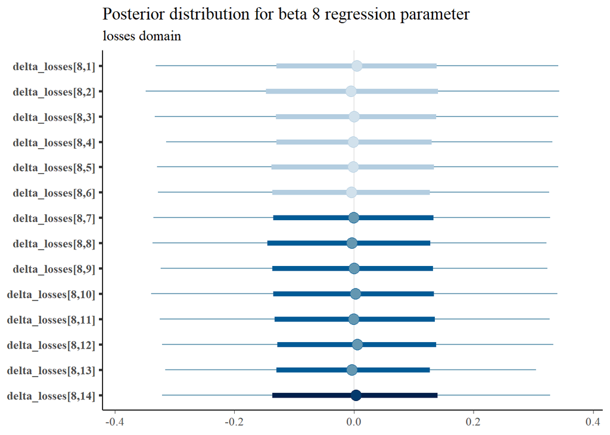

```
##
##
## [[9]]
## [[9]][[1]]
```

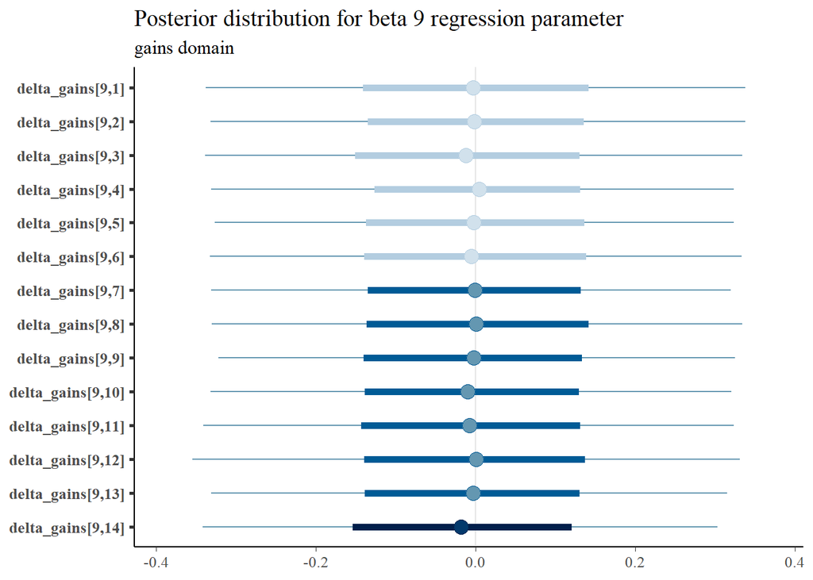

```
##
## [[9]][[2]]
```

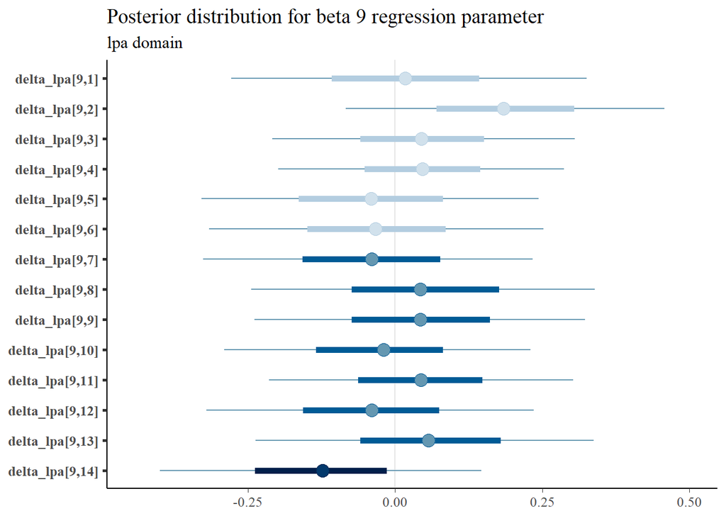

```
##
## [[9]][[3]]
```

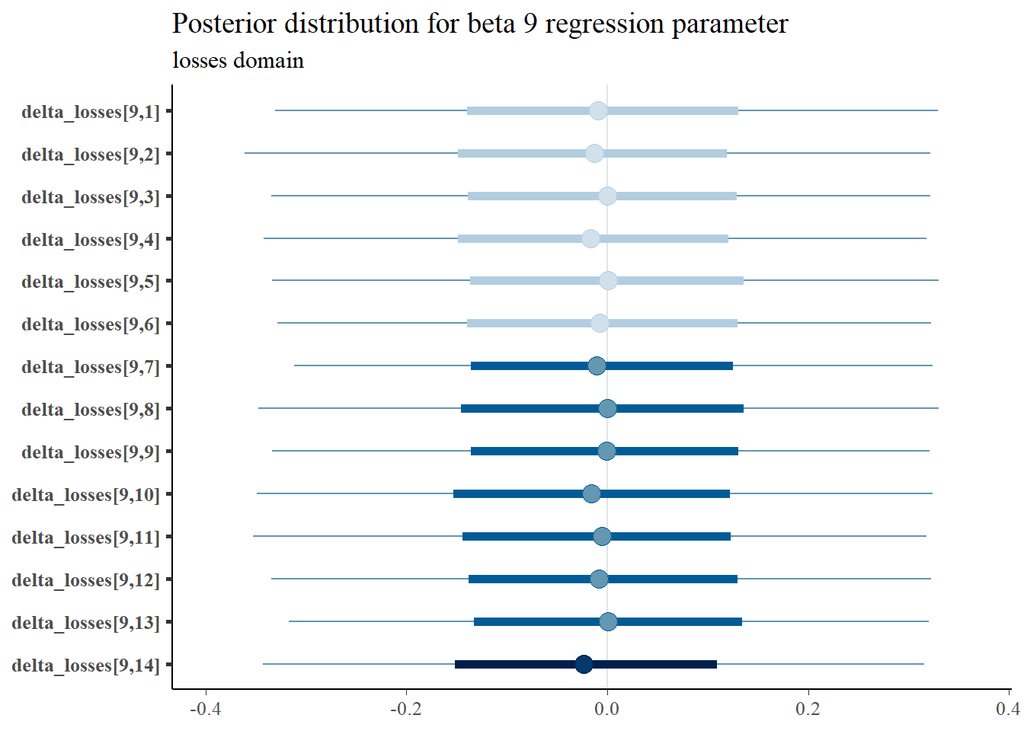

```
##
##
## [[10]]
## [[10]][[1]]
```

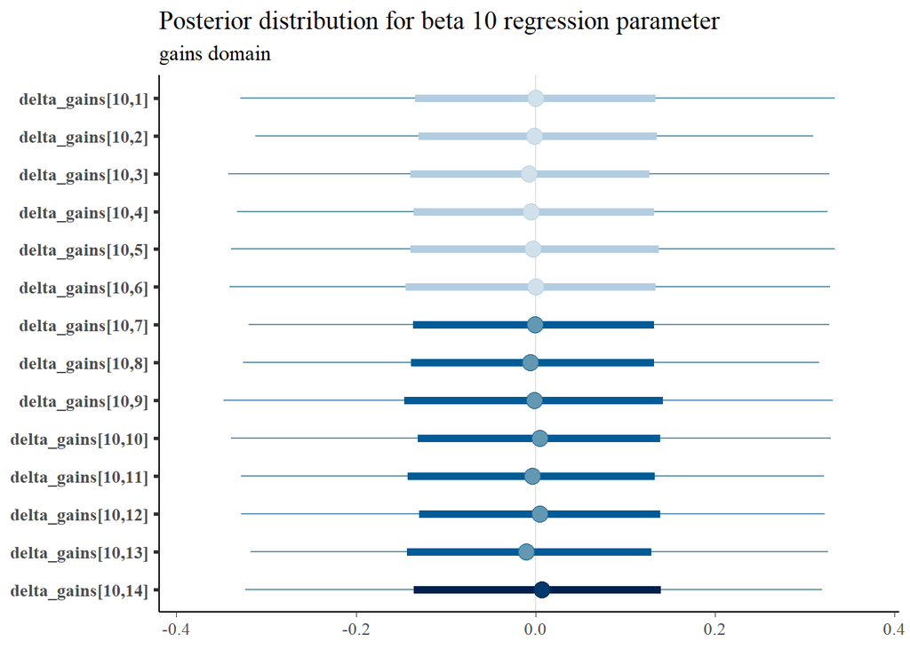

```
##
## [[10]][[2]]
```

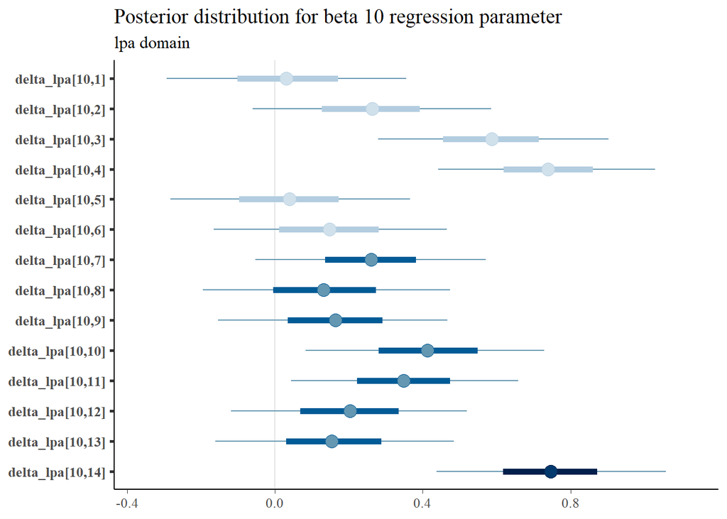

```
##
## [[10]][[3]]
```

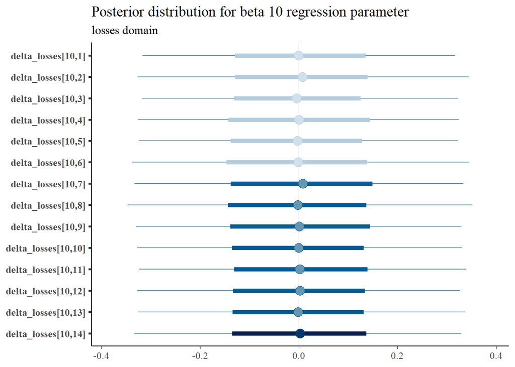

```
##
##
## [[11]]
## [[11]][[1]]
```

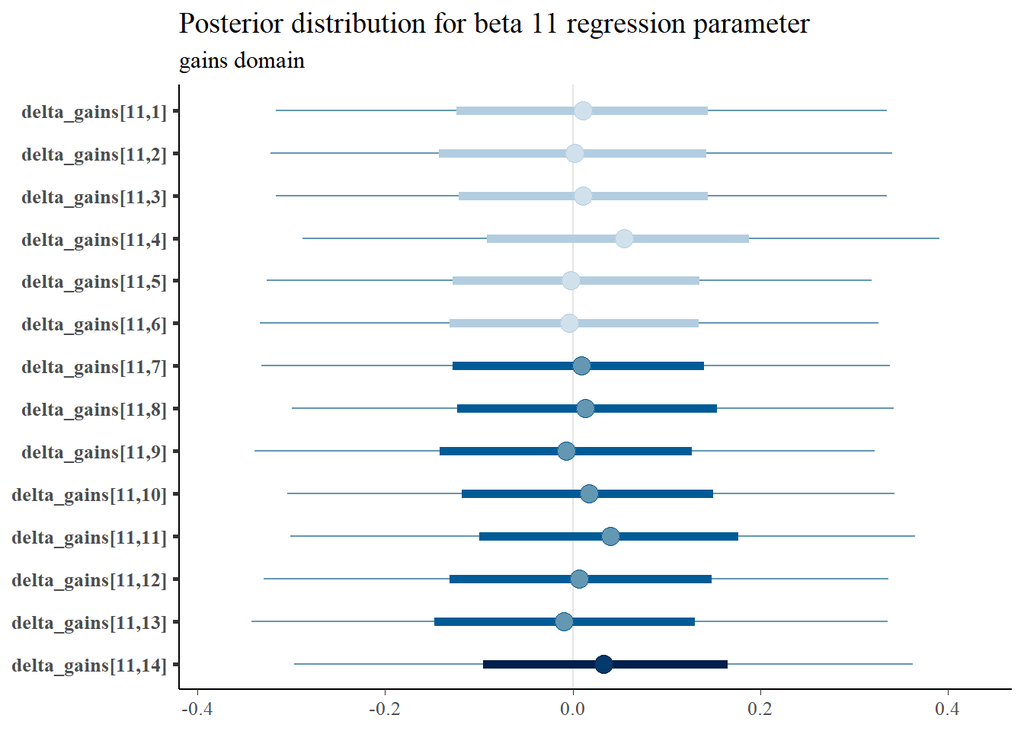

```
##
## [[11]][[2]]
```

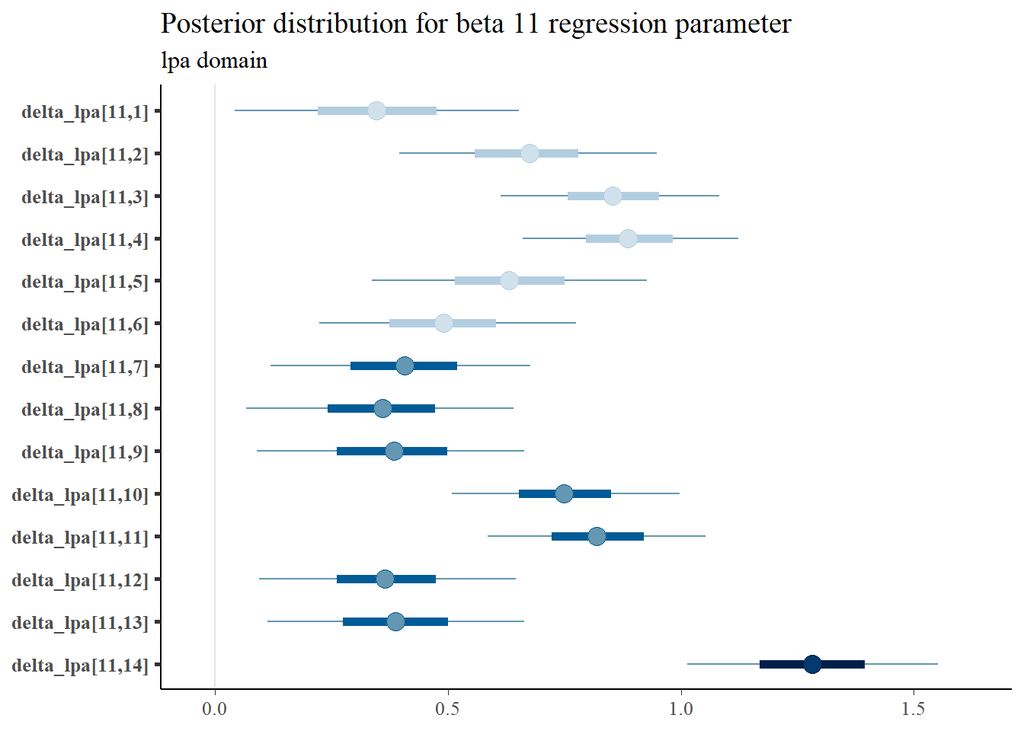

```
##
## [[11]][[3]]
```

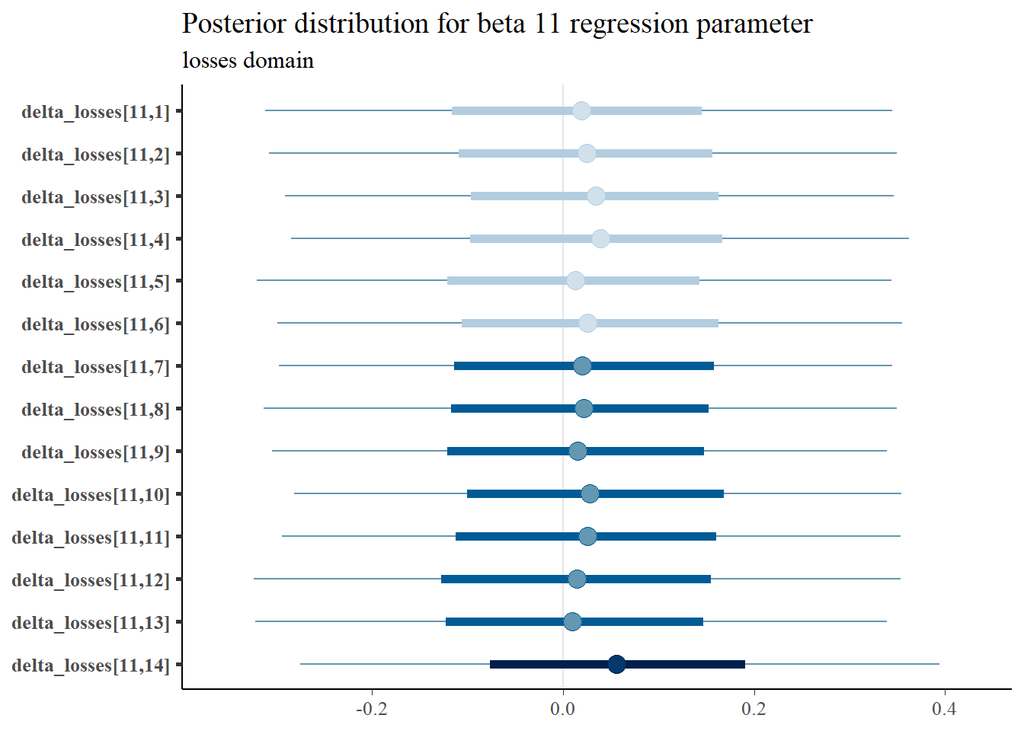

Some patterns are revealed (e.g. product 4 preferred increasingly among higher income brackets - in comparison to the highest, though; a similar, but reverse trend for product 5).

Interestingly, middle age groups and middle income groups as well as larger families have stronger incentives to buy on promotions. A similar effect is visible in brand loyalty as well.

# Subcategories

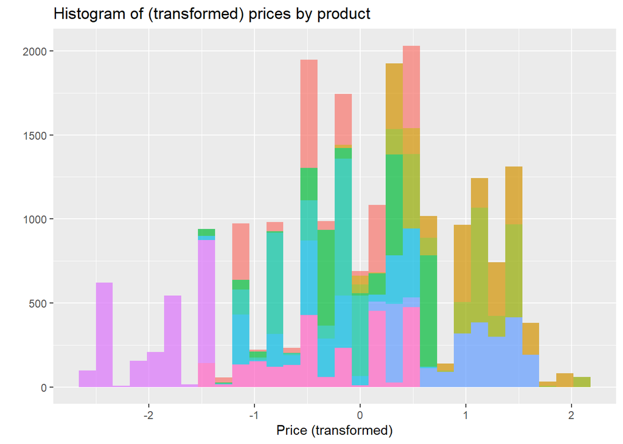

```r
ggplot(
  data.frame(
    id = as.factor( rep( 1:d$M, length( d$x))),
    price = do.call( c, lapply( d$x, function( y) y[,d$K]))
  )
) +
  geom_histogram( aes( x = price, fill = id), alpha = 0.7) +
  ggtitle( 'Histogram of (transformed) prices by product') +
  xlab( 'Price (transformed)') + ylab( '') +
  theme( legend.position = 'none')
```

Subcategories are definitely not a concern when RP of type A/B are considered.

```r
sprintf( 'Mean upper threshold was %.2f and mean lower threshold was %.2f (log scale)',
         mean( posterior[,,grep( 'r_upper', dimnames( posterior)[[3]])]) / d$scf,
         mean( posterior[,,grep( 'r_lower', dimnames( posterior)[[3]])]) / d$scf
)
```

```
## [1] "Mean upper threshold was 0.72 and mean lower threshold was -0.50 (log scale)"
```

This finding is again not very meaningful as all transactions were essentially classified into the LPA.